# R Notebook

```r
library(readr)
UsedCarLot <- read_csv("C:/Users/samee/Google Drive/College/STOR 455/R/Datasets/UsedCarLot.csv")
head(UsedCarLot)
```

| year | price | mileage | make | model |
| --- | --- | --- | --- | --- |
| 2014 | 33.888 | 17.714 | Chevrolet | Silverado |
| 2014 | 13.995 | 35.535 | VW | Jetta |
| 2013 | 9.995 | 55.800 | VW | Jetta |
| 2004 | 6.666 | 135.900 | Nissan | Altima |
| 2016 | 12.950 | 35.517 | Kia | Soul |
| 2016 | 29.877 | 15.253 | NIssan | Frontier |

```r
hondaData = subset(UsedCarLot,make == 'Honda' & model == 'Accord', select=c(year, price, mileage))
hondaData[,'age'] = 2018-hondaData$year #Create new column by subtracting 2018 from year
hondaData = subset(hondaData, select=c('price', 'mileage', 'age')) #subset again and select only the 3 columns we need for final table.
head(hondaData)
```

| price | mileage | age |
| --- | --- | --- |
| 46.995 | 16.017 | 2 |
| 37.773 | 25.516 | 2 |
| 31.999 | 29.247 | 4 |
| 33.888 | 65.652 | 2 |
| 6.999 | 177.000 | 18 |
| 31.848 | 42.134 | 2 |

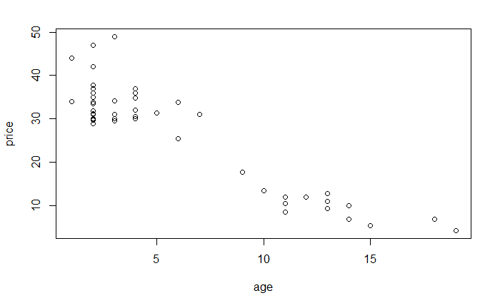

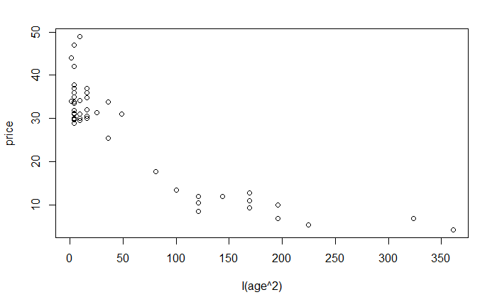

```r
quad1 = lm(price ~ age + I(age^2), data=hondaData)
plot(price ~ age + I(age^2), data=hondaData)
```

```r
plot(price) #This method will show the residuals and the qq-norm plot.
```

```
Error in plot(price) : object 'price' not found
```

Part 1b: The null hypothesis = 0 (slope 0) and the alternate hypothesis is not equal to 0 (slope 0). The p-value for age^2 is .1922 suggesting that we fail to reject the null hypothesis. The p-value is not less than .05 and suggests that a quadratic model would not be a good fit. However the p-value for age itself is 0 and seems to be a good fit.

The anova as well shows that the p-value for age is close to 0 but age^2 is .1922, suggesting that the linear model is a better fit.

```r
summary(quad1)
```

```
Call:
lm(formula = price ~ age + I(age^2), data = hondaData)

Residuals:
    Min      1Q  Median      3Q     Max
-7.2219 -3.4068 -0.7921  2.3266 15.5286

Coefficients:
            Estimate Std. Error t value Pr(>|t|)
(Intercept) 42.01832    1.81956  23.093  < 2e-16 ***
age         -2.99169    0.60969  -4.907 1.15e-05 ***
I(age^2)     0.04624    0.03494   1.323    0.192
---
Signif. codes:  0 ‘***’ 0.001 ‘**’ 0.01 ‘*’ 0.05 ‘.’ 0.1 ‘ ’ 1

Residual standard error: 5.121 on 47 degrees of freedom
Multiple R-squared:  0.8303,    Adjusted R-squared:  0.8231
F-statistic:   115 on 2 and 47 DF,  p-value: < 2.2e-16
```

```r
anova(quad1)
```

```
Analysis of Variance Table

Response: price
          Df Sum Sq Mean Sq  F value Pr(>F)
age        1 5984.0  5984.0 228.1870 <2e-16 ***
I(age^2)   1   45.9    45.9   1.7507 0.1922
Residuals 47 1232.5    26.2
---
Signif. codes:  0 ‘***’ 0.001 ‘**’ 0.01 ‘*’ 0.05 ‘.’ 0.1 ‘ ’ 1
```

Part 1c: At a 90% confidence interval, we can assume the the specific price of a car at age 7 to fall between 14.49767 to 32.18638 thousands. The exact value would be 23.34202 thousands.

```r
newx = data.frame(age=(7))
predict.lm(quad1, newx, interval='prediction', level=.9)
```

```
       fit      lwr      upr
1 23.34202 14.49767 32.18638
```

Part 1d: In order to find the specific age at where the price could equal 0 is done through a simple calculation. The formula for our quadratic equation is: Price = 42.01832 - 2.99169*Age + .04624*(Age^2) This parabola is facing up, all we have to find out is the lowest point on the parabola. We can find that using the formula -b/2a. Then we can plug in that age value and see if the price is negative or 0. If it is then the parabola has the zero/negative price phenomenon.

2.99169/2*(.04624) = 32.3495 42.01832 - 2.99169*(32.3495) + .04624*(32.3495) = -6.371651

Based on this, that means at year 32.3495, the car’s price is at the lowest at -6.371651 thousands, which makes absolutely no sense.

You can add to this and calculate the roots of the parabola, using the quadratic formula. Which is just (-b +- sqrt(b^2 - 4ac))/2a. The roots I got were, 20.61097 and 44.08821. All the years between those years gave negative prices. We can confirm that the lowest price that we calculated above is at year 32.3495 and is in this interval.

There exists an interval from 20.61097 years to 44.08821 years where the prices equal 0 and go negative.

Part 1e: Based on what we’ve discussed above, the quadratic model’s price is becoming positive after year 44.08821, because it’s a parabolic shape. This makes absolutely no sense in the real world. The negative price also doesn’t make any sense either. Nobody would pay money to take a car greater than 20.61097 years old. You could argue that the price is going up after 44.08821 years because the car becomes an antique after some years, but I doubt it.

Part 1f: Based on the summary of the cubic model we see that the adjusted r-squared went up to .8397 from .8231, the p-value for age^2 and age^3 and the intercept are significant. The residual plots scattered and the hump after year 25 seems less noticeable. The qq-norm is also good and shows a linear relationship. But the fit isn’t a significant jump.

```r
cub1 = lm(price ~ age + I(age^2) + I(age^3), data=hondaData)
summary(cub1)
```

```
Call:
lm(formula = price ~ age + I(age^2) + I(age^3), data = hondaData)

Residuals:
    Min      1Q  Median      3Q     Max
-6.5489 -3.2592 -0.7405  2.1446 14.5752

Coefficients:
             Estimate Std. Error t value Pr(>|t|)
(Intercept) 35.820321   3.088378  11.598 2.97e-15 ***
age          0.622092   1.599862   0.389   0.6992
I(age^2)    -0.410710   0.191429  -2.146   0.0372 *
I(age^3)     0.015652   0.006457   2.424   0.0193 *
---
Signif. codes:  0 ‘***’ 0.001 ‘**’ 0.01 ‘*’ 0.05 ‘.’ 0.1 ‘ ’ 1

Residual standard error: 4.874 on 46 degrees of freedom
Multiple R-squared:  0.8495,    Adjusted R-squared:  0.8397
F-statistic: 86.55 on 3 and 46 DF,  p-value: < 2.2e-16
```

```r
anova(cub1)
```

```
Analysis of Variance Table

Response: price
          Df Sum Sq Mean Sq  F value  Pr(>F)
age        1 5984.0  5984.0 251.8567 < 2e-16 ***
I(age^2)   1   45.9    45.9   1.9323 0.17120
I(age^3)   1  139.6   139.6   5.8753 0.01934 *
Residuals 46 1092.9    23.8
---
Signif. codes:  0 ‘***’ 0.001 ‘**’ 0.01 ‘*’ 0.05 ‘.’ 0.1 ‘ ’ 1
```

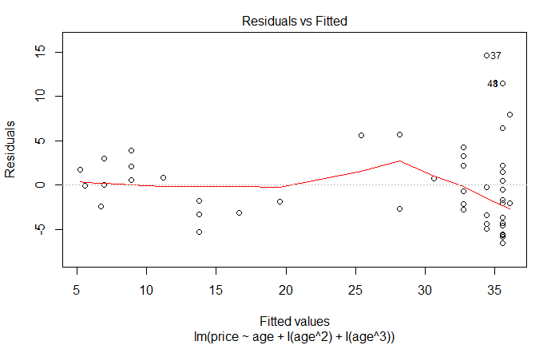

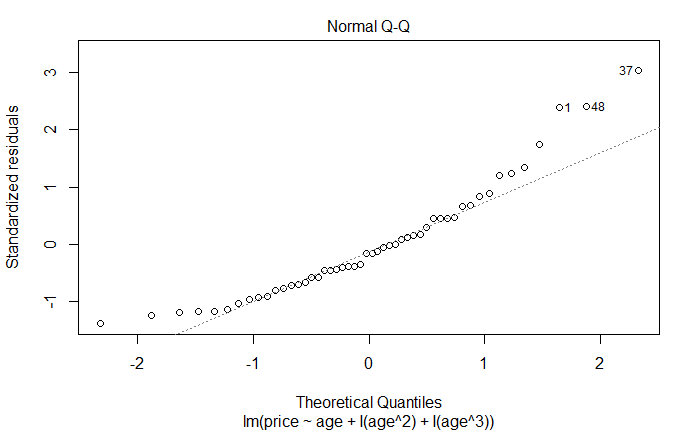

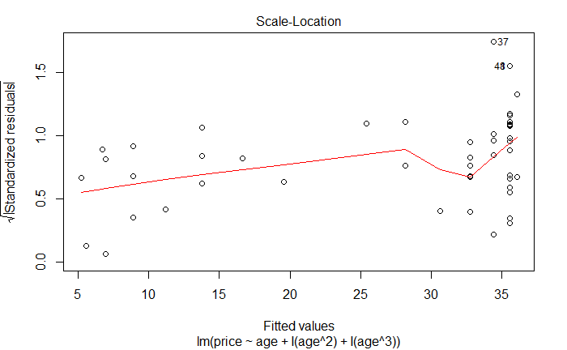

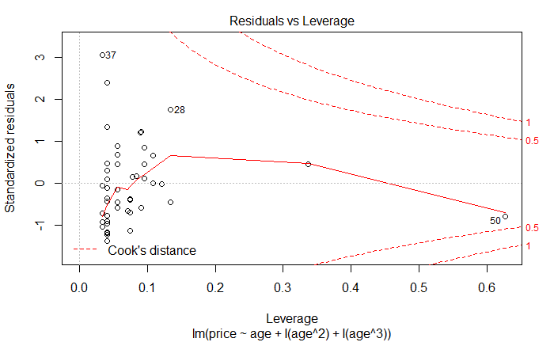

```r
plot(cub1)
```

```r
sec1 = lm(price ~ age + mileage + I(age^2) + I(mileage^2) + I(age * mileage), data=hondaData)
summary(sec1)
```

```
Call:
lm(formula = price ~ age + mileage + I(age^2) + I(mileage^2) +
    I(age * mileage), data = hondaData)

Residuals:
    Min      1Q  Median      3Q     Max
-5.5573 -3.0531 -0.8175  2.0774 16.3496

Coefficients:
                   Estimate Std. Error t value Pr(>|t|)
(Intercept)      43.4723800  1.7288502  25.145  < 2e-16 ***
age              -1.0006058  0.6910388  -1.448 0.154713
mileage          -0.2300254  0.0619104  -3.715 0.000569 ***
I(age^2)         -0.0423076  0.1324952  -0.319 0.751000
I(mileage^2)      0.0002007  0.0008043   0.250 0.804115
I(age * mileage)  0.0087736  0.0206438   0.425 0.672910
---
Signif. codes:  0 ‘***’ 0.001 ‘**’ 0.01 ‘*’ 0.05 ‘.’ 0.1 ‘ ’ 1

Residual standard error: 4.361 on 44 degrees of freedom
Multiple R-squared:  0.8848,    Adjusted R-squared:  0.8717
F-statistic: 67.57 on 5 and 44 DF,  p-value: < 2.2e-16
```

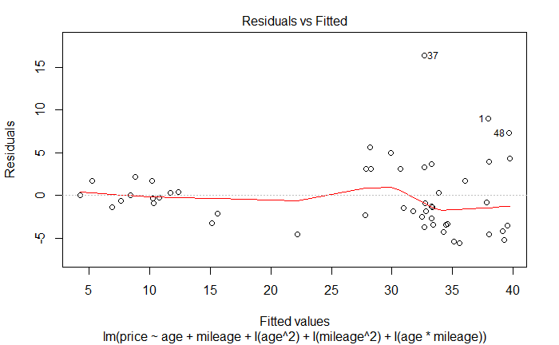

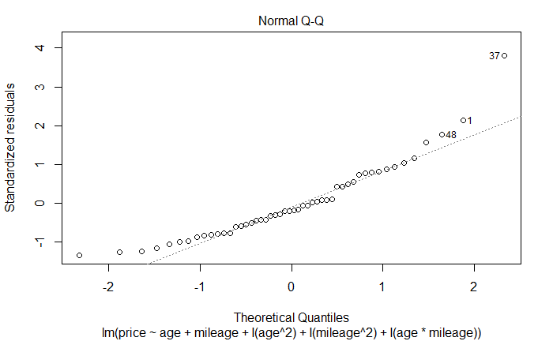

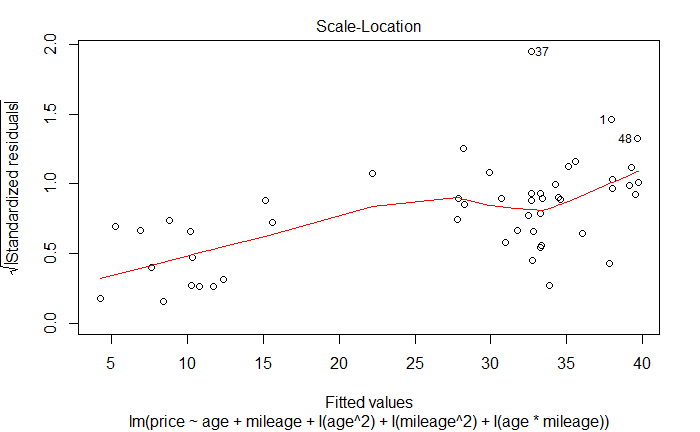

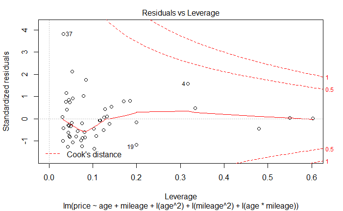

```r
plot(sec1)
```

Part 2b: Let’s assume the Null hypothesis is equal to 0 and the alternate hypothesis is not equal to 0. We see that based on this null hypothesis, we fail to reject on the age predictor (p=.154713), the age^2 predictor (p=.751000), the mileage^2 predictor (p=.804115) and the age*mileage^2 predictor (.672910). It seems that the mileage predictor itself seems to be the best predictor in this second order model. The other predictors are not significant.

Based on the anova, we see that the p-values for age (p=2.2e-16), mileage (p=0002667), mileage^2 (p=0.0225041) are the best predictors and explains the variance and the model the best.

```r
summary(sec1)
```

```
Call:
lm(formula = price ~ age + mileage + I(age^2) + I(mileage^2) +
    I(age * mileage), data = hondaData)

Residuals:
    Min      1Q  Median      3Q     Max
-5.5573 -3.0531 -0.8175  2.0774 16.3496

Coefficients:
                   Estimate Std. Error t value Pr(>|t|)
(Intercept)      43.4723800  1.7288502  25.145  < 2e-16 ***
age              -1.0006058  0.6910388  -1.448 0.154713
mileage          -0.2300254  0.0619104  -3.715 0.000569 ***
I(age^2)         -0.0423076  0.1324952  -0.319 0.751000
I(mileage^2)      0.0002007  0.0008043   0.250 0.804115
I(age * mileage)  0.0087736  0.0206438   0.425 0.672910
---
Signif. codes:  0 ‘***’ 0.001 ‘**’ 0.01 ‘*’ 0.05 ‘.’ 0.1 ‘ ’ 1

Residual standard error: 4.361 on 44 degrees of freedom
Multiple R-squared:  0.8848,    Adjusted R-squared:  0.8717
F-statistic: 67.57 on 5 and 44 DF,  p-value: < 2.2e-16
```

```r
anova(sec1)
```

```
Analysis of Variance Table

Response: price
                 Df Sum Sq Mean Sq  F value    Pr(>F)
age               1 5984.0  5984.0 314.6323 < 2.2e-16 ***
mileage           1  298.9   298.9  15.7174 0.0002667 ***
I(age^2)          1   32.9    32.9   1.7278 0.1954982
I(mileage^2)      1  106.4   106.4   5.5933 0.0225041 *
I(age * mileage)  1    3.4     3.4   0.1806 0.6729101
Residuals        44  836.8    19.0
---
Signif. codes:  0 ‘***’ 0.001 ‘**’ 0.01 ‘*’ 0.05 ‘.’ 0.1 ‘ ’ 1
```

Part 2c: The null hypothesis is that the full model is not significant. And the alternate hypothesis is that the full model is signficant. After performing the anova, we get a p-value of .07178, we fail to reject the null-hypothesis. The full model is not more siginificant than the alternate hypothesis at an alpha value of .05.

In conclusion, The reduced model with just age and mileage is good enough and the full model doesn’t seem to add a lot of significance at an alpha value of .05. Although, .07178 is still a good p-value. The interaction and the quadratic do not add a lot of signficance.

```r
reduced = lm(price ~ age + mileage, data = hondaData)
full = lm(price ~ age + mileage + I(age^2) + I(mileage^2) + I(age * mileage), data = hondaData)
anova(reduced, full)
```

```
Analysis of Variance Table

Model 1: price ~ age + mileage
Model 2: price ~ age + mileage + I(age^2) + I(mileage^2) + I(age * mileage)
  Res.Df    RSS Df Sum of Sq      F  Pr(>F)
1     47 979.51
2     44 836.83  3    142.67 2.5006 0.07178 .
---
Signif. codes:  0 ‘***’ 0.001 ‘**’ 0.01 ‘*’ 0.05 ‘.’ 0.1 ‘ ’ 1
```

Part 2d: The null hypothesis is that the full model is not significant. And the alternate hypothesis is that the full model is signficant. After performing the anova, we get a p-value of .0006361, which means that we reject the null-hypothesis.

In conclusion, this suggests that the model with mileage (the full model) is definitely much more significant and better compared to the reduced model without any mileage in it.

```r
reduced = lm(price ~ age + I(age^2), data = hondaData)
full = lm(price ~ age + mileage + I(age^2) + I(mileage^2) + I(age * mileage), data = hondaData)
anova(reduced, full)
```

```
Analysis of Variance Table

Model 1: price ~ age + I(age^2)
Model 2: price ~ age + mileage + I(age^2) + I(mileage^2) + I(age * mileage)
  Res.Df     RSS Df Sum of Sq      F    Pr(>F)
1     47 1232.52
2     44  836.83  3    395.69 6.9351 0.0006361 ***
---
Signif. codes:  0 ‘***’ 0.001 ‘**’ 0.01 ‘*’ 0.05 ‘.’ 0.1 ‘ ’ 1
```

Also the higher power models do not make sense, because of their intervals of negative to positive and negative. The phenomenon is extreme.